# June 21, 2014

# PREDICTING QUALITY OF BARBELL LIFTING ACTIVITY

Exercise devices commonly measure quantity of exercise activity rather than quality. A recent study “Qualitative Activity Recognition of Weight Lifting Exercises”(see reference below) gives focus to this more meaningful aspect of exercise activity, using data from Human Activity Recognition (HAR). In this practical machine learning study, I use the data from the Weight Lifting Exercises data set to apply a Random Forest model. The description of the original weight lifting study can be located at the following URL site:

```
    http://groupware.les.inf.puc-rio.br/har
```

The training data set is available at:

```
    https://d396qusza40orc.cloudfront.net/predmachlearn/pml-training.csv
```

The test data set is available at:

```
    https://d396qusza40orc.cloudfront.net/predmachlearn/pml-testing.csv
```

The markdown file makes use of R language in R version 3.0.3 (2014-03-06), “Warm Puppy” on platform “x86_64-apple-darwin10.8.0”.

# DESCRIPTION OF OUTCOME VARIABLE: CLASSE

The outcome variable is `classe` and has factor levels labeled A-E, which corresponds to one of the five categories of  
Unilateral Dumbbell Biceps Curl: A) performed correctly according to specification; B) incorrectly throwing elbow to front; C) incorrectly lifting the dumbbell only halfway; D) incorrectly lowering the dumbbell only halfway; and E) incorrectly throwing the hips to the front. Thus, category A is the only correct activity while the remaining four, B-E, describe incorrect activities. The distribution of the outcome variable is shown below in a bar plot.

```r
setwd("/Users/karenyang/Desktop/PracticalMachineLearning")
download.file("https://d396qusza40orc.cloudfront.net/predmachlearn/pml-training.csv",
              destfile="pml-training.csv",method="curl")
download.file("https://d396qusza40orc.cloudfront.net/predmachlearn/pml-testing.csv",
              destfile="pml-testing.csv",method="curl")
train <- read.csv("pml-training.csv")
test <- read.csv("pml-testing.csv")
print(object.size(train),units="Mb")
```

```
## 19 Mb
```

```r
object.size(test)
```

```
## 43480 bytes
```

```r
dim(train)
```

```
## [1] 19622   160
```

```r
dim(test)
```

```
## [1]  20 160
```

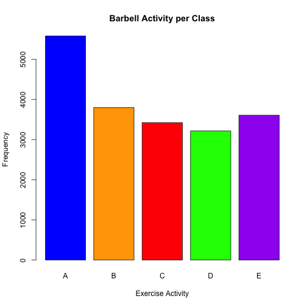

```r
# Look at distribution of outcome variable called classe
barplot(table(train$classe), col = c("blue","orange","red","green","purple"),ylab="Frequency",
        xlab="Exercise Activity", main = "Barbell Activity per Class")
```

For the original study, six young health males between the ages of 20 to 28 were asked to perform one set of 10 repetitions of the Unilateral Dumbbell Biceps Curl in five different ways, using a light weight of only 1.25 kg for safety reasons. While these 6 participants were inexperienced weight lifters, they were under the supervision of an experienced weight lifter. Below is the distribution of exercise activity per participant as captured by number of windows (each window is 2.5 seconds).

```r
# Plot
install.packages("ggplot2")
```

[output not shown]

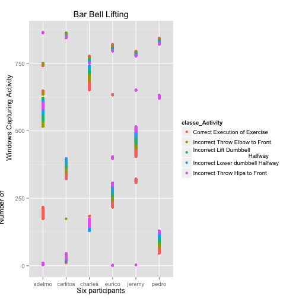

```r
library(ggplot2)
train$classe_Activity <-train$classe
levels(train$classe_Activity) <- c("Correct Execution of Exercise","Incorrect Throw Elbow to Front","Incorrect Lift Dumbbell
                                   Halfway","Incorrect Lower dumbbell Halfway","Incorrect Throw Hips to Front")
qplot(user_name, num_window, data=train,color=classe_Activity,xlab="Six participants",ylab=expression("Number of
                                Windows Capturing Activity"),main=expression("Bar Bell Lifting"))
```

```r
train$classe_Activity <- NULL
```

# REMOVING COLUMNS FILLED WITH MISSING VALUES, SUBSETTING, AND PARTITIONING DATA SET

A function was used to identify the number of columns that were completely filled with missing values. The train data set was subsetted accordingly. A second sub-setting of the data set was performed to remove the sliding windows and time stamp variables: `new_window`, `num_window`, `raw_timestamp_part_1`,`raw_timestamp_part_2`,`cvtd_timestamp`. Also, the serial counter variable `X`, the participant name `user_name`, and all factor variables were removed. An additional variable, `yaw_arm.1` was removed because of discrepancy between the training and test data sets. Thus, the `train2` data set has 52 continuous predictors to match the test data set. Finally, the train data set was partitioned in a 70-30 split with 70% of the data allocated for building the model, using the `training` data set and the remaining 30% of the data allocated to tune and test the model, using the `validation` data set.

```r
# Find the sum of NAs per column in data set; write a function
columnNAs <- function(y) {
     nc <- ncol(y)
     cNAs <- numeric(nc)
     for (i in 1:nc) {
            cNAs[i] <- sum(is.na(y[,i]))
     }
     cNAs
}
# call the function
columnNAs(train)
```

```
##   [1]     0     0     0     0     0     0     0     0     0     0     0
##  [12]     0     0     0     0     0     0 19216 19216     0 19216 19216
##  [23]     0 19216 19216     0 19216 19216 19216 19216 19216 19216 19216
##  [34] 19216 19216 19216     0     0     0     0     0     0     0     0
##  [45]     0     0     0     0     0 19216 19216 19216 19216 19216 19216
##  [56] 19216 19216 19216 19216     0     0     0     0     0     0     0
##  [67]     0     0     0     0     0     0     0     0 19216 19216 19216
##  [78] 19216 19216 19216 19216 19216 19216     0     0     0     0     0
##  [89]     0     0     0     0 19216 19216     0 19216 19216     0 19216
## [100] 19216     0     0 19216 19216 19216 19216 19216 19216 19216 19216
## [111] 19216 19216     0     0     0     0     0     0     0     0     0
## [122]     0     0     0     0     0     0     0     0     0 19216 19216
## [133]     0 19216 19216     0 19216 19216     0     0 19216 19216 19216
## [144] 19216 19216 19216 19216 19216 19216 19216     0     0     0     0
## [155]     0     0     0     0     0     0
```

```r
# Find columns that are NOT all NAs
which(columnNAs(train)!=19216)
```

```
##  [1]   1   2   3   4   5   6   7   8   9  10  11  12  13  14  15  16  17
## [18]  20  23  26  37  38  39  40  41  42  43  44  45  46  47  48  49  60
## [35]  61  62  63  64  65  66  67  68  69  70  71  72  73  74  84  85  86
## [52]  87  88  89  90  91  92  95  98 101 102 113 114 115 116 117 118 119
## [69] 120 121 122 123 124 125 126 127 128 129 130 133 136 139 140 151 152
## [86] 153 154 155 156 157 158 159 160
```

```r
# Subset train data set by columns that are NOT all NAs
train1 <- train[,which(columnNAs(train)!=19216)]
dim(train1)
```

```
## [1] 19622    93
```

```r
# Subset data set further to have only continous variables related to barbell lifting
train2 <-train1[c(8,9,10,11,21,22,23,24,25,26,27,28,29,30,31,32,32,33,34,35,36,37
                  ,38,39,40,41,42,49,50,51,61,62,63,64,65,66,67,68,69,70,71,72,73
                  ,83,84,85,86,87,88,89,90,91,92,93)]
dim(train2)
```

```
## [1] 19622    54
```

```r
train2$yaw_arm.1 <- NULL # This variable not in test data set so remove
str(train2)
```

```
## 'data.frame':    19622 obs. of  53 variables:
##  $ roll_belt           : num  1.41 1.41 1.42 1.48 1.48 1.45 1.42 1.42 1.43 1.45 ...
##  $ pitch_belt          : num  8.07 8.07 8.07 8.05 8.07 8.06 8.09 8.13 8.16 8.17 ...
##  $ yaw_belt            : num  -94.4 -94.4 -94.4 -94.4 -94.4 -94.4 -94.4 -94.4 -94.4 -94.4 ...
##  $ total_accel_belt    : int  3 3 3 3 3 3 3 3 3 3 ...
##  $ gyros_belt_x        : num  0 0.02 0 0.02 0.02 0.02 0.02 0.02 0.02 0.03 ...
##  $ gyros_belt_y        : num  0 0 0 0 0.02 0 0 0 0 0 ...
##  $ gyros_belt_z        : num  -0.02 -0.02 -0.02 -0.03 -0.02 -0.02 -0.02 -0.02 -0.02 0 ...
##  $ accel_belt_x        : int  -21 -22 -20 -22 -21 -21 -22 -22 -20 -21 ...
##  $ accel_belt_y        : int  4 4 5 3 2 4 3 4 2 4 ...
##  $ accel_belt_z        : int  22 22 23 21 24 21 21 21 24 22 ...
##  $ magnet_belt_x       : int  -3 -7 -2 -6 -6 0 -4 -2 1 -3 ...
##  $ magnet_belt_y       : int  599 608 600 604 600 603 599 603 602 609 ...
##  $ magnet_belt_z       : int  -313 -311 -305 -310 -302 -312 -311 -313 -312 -308 ...
##  $ roll_arm            : num  -128 -128 -128 -128 -128 -128 -128 -128 -128 -128 ...
```

[output cut: 39 more lines]

```r
# Make the test data set like the training data set in terms of the same predictors
# call the function
columnNAs(test)
```

```
##   [1]  0  0  0  0  0  0  0  0  0  0  0 20 20 20 20 20 20 20 20 20 20 20 20
##  [24] 20 20 20 20 20 20 20 20 20 20 20 20 20  0  0  0  0  0  0  0  0  0  0
##  [47]  0  0  0 20 20 20 20 20 20 20 20 20 20  0  0  0  0  0  0  0  0  0 20
##  [70] 20 20 20 20 20 20 20 20 20 20 20 20 20 20  0  0  0 20 20 20 20 20 20
##  [93] 20 20 20 20 20 20 20 20 20  0 20 20 20 20 20 20 20 20 20 20  0  0  0
## [116]  0  0  0  0  0  0  0  0  0 20 20 20 20 20 20 20 20 20 20 20 20 20 20
## [139] 20  0 20 20 20 20 20 20 20 20 20 20  0  0  0  0  0  0  0  0  0  0
```

```r
# Find columns that are NOT all NAs
which(columnNAs(test)!=20)
```

```
##  [1]   1   2   3   4   5   6   7   8   9  10  11  37  38  39  40  41  42
## [18]  43  44  45  46  47  48  49  60  61  62  63  64  65  66  67  68  84
## [35]  85  86 102 113 114 115 116 117 118 119 120 121 122 123 124 140 151
## [52] 152 153 154 155 156 157 158 159 160
```

```r
# Subset train data set by columns that are NOT all NAs
test1 <- test[,which(columnNAs(test)!=20)]
test2 <-test1[c(-1,-2,-3,-4,-5,-6,-7)]
str(test2)
```

```
## 'data.frame':    20 obs. of  53 variables:
##  $ roll_belt           : num  123 1.02 0.87 125 1.35 -5.92 1.2 0.43 0.93 114 ...
##  $ pitch_belt          : num  27 4.87 1.82 -41.6 3.33 1.59 4.44 4.15 6.72 22.4 ...
##  $ yaw_belt            : num  -4.75 -88.9 -88.5 162 -88.6 -87.7 -87.3 -88.5 -93.7 -13.1 ...
##  $ total_accel_belt    : int  20 4 5 17 3 4 4 4 4 18 ...
##  $ gyros_belt_x        : num  -0.5 -0.06 0.05 0.11 0.03 0.1 -0.06 -0.18 0.1 0.14 ...
##  $ gyros_belt_y        : num  -0.02 -0.02 0.02 0.11 0.02 0.05 0 -0.02 0 0.11 ...
##  $ gyros_belt_z        : num  -0.46 -0.07 0.03 -0.16 0 -0.13 0 -0.03 -0.02 -0.16 ...
##  $ accel_belt_x        : int  -38 -13 1 46 -8 -11 -14 -10 -15 -25 ...
##  $ accel_belt_y        : int  69 11 -1 45 4 -16 2 -2 1 63 ...
##  $ accel_belt_z        : int  -179 39 49 -156 27 38 35 42 32 -158 ...
##  $ magnet_belt_x       : int  -13 43 29 169 33 31 50 39 -6 10 ...
##  $ magnet_belt_y       : int  581 636 631 608 566 638 622 635 600 601 ...
##  $ magnet_belt_z       : int  -382 -309 -312 -304 -418 -291 -315 -305 -302 -330 ...
##  $ roll_arm            : num  40.7 0 0 -109 76.1 0 0 0 -137 -82.4 ...
```

[output cut: 39 more lines]

```r
# Check variables are same across train and test data sets
colnames(train2)==colnames(test2)
```

```
##  [1]  TRUE  TRUE  TRUE  TRUE  TRUE  TRUE  TRUE  TRUE  TRUE  TRUE  TRUE
## [12]  TRUE  TRUE  TRUE  TRUE  TRUE  TRUE  TRUE  TRUE  TRUE  TRUE  TRUE
## [23]  TRUE  TRUE  TRUE  TRUE  TRUE  TRUE  TRUE  TRUE  TRUE  TRUE  TRUE
## [34]  TRUE  TRUE  TRUE  TRUE  TRUE  TRUE  TRUE  TRUE  TRUE  TRUE  TRUE
## [45]  TRUE  TRUE  TRUE  TRUE  TRUE  TRUE  TRUE  TRUE FALSE
```

```r
colnames(train2[53]) # labeled "classe"--actual outcomes
```

```
## [1] "classe"
```

```r
colnames(test2[53])  # labeled "problem_id"--serial counter
```

```
## [1] "problem_id"
```

```r
# Use caret package
install.packages("caret")
```

[output not shown]

```r
library(caret)
# Partition data set between training and validation
set.seed(1212)
intrain <- createDataPartition(train2$classe, p = 0.7, list = FALSE)
training = train2[intrain, ] # 70% split
dim(training)
```

```
## [1] 13737    53
```

```r
validation <- train2[-intrain, ] # 30% split
dim(validation)
```

```
## [1] 5885   53
```

# BUILD RANDOM FOREST MODEL, USING TRAINING DATA SET

Random Forest is used for the purpose of feature selection. It does so by growing many trees, hence a forest, through bootstrap sampling (sampling with replacement). At each node, a subset of predictors, say m, is selected at random out of M total predictors. The best split on these m is used to split the node. m is held constant as the forest grows.

According to Leo Breiman and Adele Cutler, cross-validation is estimated internally so a separate test set to obtain the unbiased estimate of the test set error is not needed. Each tree is grown using a different bootstrap sample such that about one-third of the cases are set aside and not used in the tree construction. This reserved one-third portion is used get a classification. j is the class that got most of the votes every time case n was out of bag. An out of bag error estimate is obtained by taking the average of the the proportion of times that class j is not equal to the true class of n when n was out of bag. This gives an unbiased estimate.

I expect the error rate for the model's predicted values to be overly optimistic since the model is built from the training data set from which it was generated from. The expectation is that the model's error rate for the validation data set, would be a more reliable estimate, lower than the error rate from the training data set, since it is an independent entity from which to gauge how well the model performed in terms of its correct or incorrect classification.

```r
# For training data set
# source: http://www.stat.berkeley.edu/~breiman/RandomForests/cc_home.htm#ooberr
set.seed(1313)
tc <- trainControl(method = "oob")

set.seed(1414)
modelFit1 <- train(training$classe ~.,data=training,method="rf",prox=TRUE,importance=TRUE,trControl=tc)
print(modelFit1)
```

```
## Random Forest
##
## 13737 samples
##    52 predictors
##     5 classes: 'A', 'B', 'C', 'D', 'E'
##
## No pre-processing
## Resampling: Out of Bag Resampling
##
## Summary of sample sizes:
##
## Resampling results across tuning parameters:
##
##   mtry  Accuracy  Kappa
##   2     1         1
##   30    1         1
##   50    1         1
##
## Accuracy was used to select the optimal model using  the largest value.
## The final value used for the model was mtry = 2.
```

```r
print(modelFit1$finalModel)
```

```
##
## Call:
##  randomForest(x = x, y = y, mtry = param$mtry, importance = TRUE,      proximity = TRUE)
##                Type of random forest: classification
##                      Number of trees: 500
## No. of variables tried at each split: 2
##
##         OOB estimate of  error rate: 0.72%
## Confusion matrix:
##      A    B    C    D    E class.error
## A 3903    2    0    0    1    0.000768
## B   20 2632    6    0    0    0.009782
## C    0   20 2373    3    0    0.009599
## D    0    0   41 2210    1    0.018650
## E    0    0    1    4 2520    0.001980
```

```r
# Don't report prediction for training data set as model will be overly optimistic
# prediction_train <- predict(modelFit1, newdata=training)
# confusionMatrix(prediction_train, training$classe)  # Accuracy is 1 (no errors)

# Show variable importance plot
variable_importance <-varImp(modelFit1,scale=FALSE)
variable_importance
```

```
## rf variable importance
##
##   variables are sorted by maximum importance across the classes
##   only 20 most important variables shown (out of 52)
##
##                      A    B    C    D    E
## yaw_belt          35.9 35.9 31.4 38.0 28.6
## pitch_belt        29.9 37.2 29.5 31.4 30.1
## roll_belt         29.0 35.5 33.4 35.5 27.5
## roll_arm          24.5 33.3 30.7 29.6 25.0
## yaw_arm           21.2 28.9 26.5 30.0 25.6
## gyros_belt_z      23.1 29.9 23.8 24.4 24.5
## pitch_forearm     24.7 29.0 27.2 29.8 27.2
## magnet_dumbbell_z 28.7 26.7 29.7 26.8 25.3
## magnet_forearm_z  22.1 27.6 24.7 29.7 26.8
## magnet_dumbbell_y 23.5 26.3 29.3 25.5 22.8
## magnet_dumbbell_x 22.7 24.9 28.8 23.7 22.0
## roll_dumbbell     23.4 25.7 28.8 26.1 23.9
## accel_dumbbell_y  26.4 28.8 27.2 27.4 27.1
## accel_belt_z      24.5 28.7 27.8 25.0 24.6
## accel_dumbbell_z  23.7 26.2 28.4 26.5 27.8
## magnet_belt_z     24.6 28.3 27.3 28.3 24.8
## accel_forearm_z   22.4 28.3 26.6 25.9 26.6
## gyros_forearm_y   20.0 28.2 25.8 24.9 21.5
## accel_dumbbell_x  21.7 27.4 26.0 23.1 24.9
## accel_arm_y       21.0 27.4 23.2 25.8 24.8
```

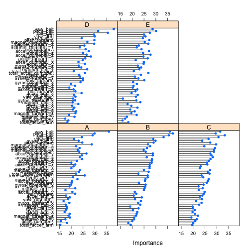

```r
plot(variable_importance)
```

# UN-TUNED MODEL APPLIED TO VALIDATION AND TEST DATA SETS

In this part, I apply the un-tuned model to the validation data set. Basically, this model uses all predictors to obtain the predicted values for the validation data set. The classification rate (correct and incorrect) is obtained via the Confusion Matrix. Finally, the un-tuned model is applied to the test data set to obtain predictions for 20 observations.

```r
# For validation data set--the un-tuned model uses all predictors
prediction_valid <- predict(modelFit1, newdata=validation)
# Out-of-sample error rate (classification rate)
confusionMatrix(prediction_valid,validation$classe)
```

```
## Confusion Matrix and Statistics
##
##           Reference
## Prediction    A    B    C    D    E
##          A 1674    3    0    0    0
##          B    0 1131    5    0    0
##          C    0    5 1020   19    0
##          D    0    0    1  942    2
##          E    0    0    0    3 1080
##
## Overall Statistics
##
##                Accuracy : 0.994
##                  95% CI : (0.991, 0.995)
##     No Information Rate : 0.284
##     P-Value [Acc > NIR] : <2e-16
##
##                   Kappa : 0.992
##  Mcnemar's Test P-Value : NA
##
## Statistics by Class:
##
##                      Class: A Class: B Class: C Class: D Class: E
## Sensitivity             1.000    0.993    0.994    0.977    0.998
## Specificity             0.999    0.999    0.995    0.999    0.999
## Pos Pred Value          0.998    0.996    0.977    0.997    0.997
## Neg Pred Value          1.000    0.998    0.999    0.996    1.000
## Prevalence              0.284    0.194    0.174    0.164    0.184
## Detection Rate          0.284    0.192    0.173    0.160    0.184
## Detection Prevalence    0.285    0.193    0.177    0.161    0.184
## Balanced Accuracy       1.000    0.996    0.995    0.988    0.999
```

```r
# prediction for held out data set-- test data set uses all  predictors
prediction_test1 <- predict(modelFit1,newdata=test2)

# Predictions for 20 observations
prediction_test1
```

```
##  [1] B A B A A E D B A A B C B A E E A B B B
## Levels: A B C D E
```

# TUNED MODEL APPLIED TO VALIDATION AND TEST DATA SETS

Here, I take the top 20 variables of importance and create a new training data set called `training_tuned`. I set the train control method to be out of bag and run a second model fit with this data set of 20 variables. I then apply `modelFit2` to the validation data set and obtain the classification rate, using the Confusion Matrix. Comparing the classification rate of the un-tuned model against the tuned model gives us a way to evaluate model performance.

```r
# For validation data set--the tuned model using 20 predictors with outcome variable
training_tuned <-training[c(1,2,3,7,10,13,14,16,22,27,34,35,36,37,38,39,41,48,49,52,53)]
set.seed(1313)
tc <- trainControl(method = "oob")
set.seed(1515)
modelFit2 <- train(training_tuned$classe ~.,data=training_tuned,method="rf",prox=TRUE,importance=TRUE,trControl=tc)
print(modelFit2)
```

```
## Random Forest
##
## 13737 samples
##    20 predictors
##     5 classes: 'A', 'B', 'C', 'D', 'E'
##
## No pre-processing
## Resampling: Out of Bag Resampling
##
## Summary of sample sizes:
##
## Resampling results across tuning parameters:
##
##   mtry  Accuracy  Kappa
##   2     1         1
##   10    1         1
##   20    1         1
##
## Accuracy was used to select the optimal model using  the largest value.
## The final value used for the model was mtry = 2.
```

```r
print(modelFit2$finalModel)
```

```
##
## Call:
##  randomForest(x = x, y = y, mtry = param$mtry, importance = TRUE,      proximity = TRUE)
##                Type of random forest: classification
##                      Number of trees: 500
## No. of variables tried at each split: 2
##
##         OOB estimate of  error rate: 0.92%
## Confusion matrix:
##      A    B    C    D    E class.error
## A 3894    9    1    1    1    0.003072
## B   29 2608   18    2    1    0.018811
## C    0   18 2372    6    0    0.010017
## D    1    0   25 2224    2    0.012433
## E    0    0    3   10 2512    0.005149
```

```r
# prediction for validation data set
prediction_valid2 <- predict(modelFit2, newdata=validation[c(1,2,3,7,10,13,14,16,22,27,34,35,36,37,38,39,41,48,49,52,53)])
confusionMatrix(prediction_valid2,validation$classe)
```

```
## Confusion Matrix and Statistics
##
##           Reference
## Prediction    A    B    C    D    E
##          A 1674   12    0    0    0
##          B    0 1118    4    0    1
##          C    0    8 1018   10    2
##          D    0    1    4  951    3
##          E    0    0    0    3 1076
##
## Overall Statistics
##
##                Accuracy : 0.992
##                  95% CI : (0.989, 0.994)
##     No Information Rate : 0.284
##     P-Value [Acc > NIR] : <2e-16
##
##                   Kappa : 0.99
##  Mcnemar's Test P-Value : NA
##
## Statistics by Class:
##
##                      Class: A Class: B Class: C Class: D Class: E
## Sensitivity             1.000    0.982    0.992    0.987    0.994
## Specificity             0.997    0.999    0.996    0.998    0.999
## Pos Pred Value          0.993    0.996    0.981    0.992    0.997
## Neg Pred Value          1.000    0.996    0.998    0.997    0.999
## Prevalence              0.284    0.194    0.174    0.164    0.184
## Detection Rate          0.284    0.190    0.173    0.162    0.183
## Detection Prevalence    0.286    0.191    0.176    0.163    0.183
## Balanced Accuracy       0.999    0.990    0.994    0.992    0.997
```

```r
# Apply tuned model to test data set
prediction_test2 <- predict(modelFit2,newdata=test2[c(1,2,3,7,10,13,14,16,22,27,34,35,36,37,38,39,41,48,49,52,53)])
prediction_test2
```

```
##  [1] B A B A A E D B A A B C B A E E A B B B
## Levels: A B C D E
```

# SUMMARY

Can a tuned model perform the same, or possibly better than, the un-tuned model? I used the the variable importance plot across all five factor categories to identify a subset of predictors that can be used to make a tuned model. Of the 52 predictors, I select the top 20 variable of importance, identified by the first model fit, and applied it against the training data set to generate a second model fit. Again, I apply the model to the validation data set and obtain an accuracy rate of 0.9918, essentially the same result of 99%. So, the tuned model performs equally well as the un-tuned model. Further, using the test data set, the tuned model correctly predicts all 20 observations. If given a choice between the un-tuned or tuned model, given that they performed equally well on the validation data set and made correct predictions on the test data set, I would choose the tuned model since it is simpler and it is the raison d'etre for using random forest,namely feature selection.

# REFERENCES

Velloso, E.; Bulling, A.; Gellersen, H.; Ugulino, W.; Fuks, H. Qualitative Activity Recognition of Weight Lifting Exercises. Proceedings of 4th International Conference in Cooperation with SIGCHI (Augmented Human '13) . Stuttgart, Germany: ACM SIGCHI, 2013.

Random Forests by Leo Breiman and Adele Cutler. URL: http://www.stat.berkeley.edu/%7Ebreiman/RandomForests/cc_home.htm. Accessed 6/18/2014.

Coursera: “Practical Machine Learning”. Online course given by Jeff Leek. The Johns Hopkins Bloomberg School of Public Health. Dates: June 18-22, 2014. URL: https://class.coursera.org/predmachlearn-002.